# Сообщества Макрозообентоса Обской губы

## Литература

Sparrevik E., Leonardsson K. Recruitment in the predacious isopod Saduria entomon (L.): alternative prey reduces cannibalism //Journal of Experimental Marine Biology and Ecology. – 1998. – Т. 221. – №. 1. – С. 117-130.

Bergström U., Englund G. Estimating predation rates in experimental systems: scale‐dependent effects of aggregative behaviour //Oikos. – 2002. – Т. 97. – №. 2. – С. 251-259.

Kube, J., Zettler, M. L., Gosselck, F., Ossig, S. and Powilleit, M., 1996. Distribution of Marenzelleria viridis (Verrill, 1873) (Polychaeta: Spionidae) in the southwestern Baltic Sea in 1993/94—ten years after introduction.Sarsia 81: 131–142.

Kauppi L., Norkko A., Norkko J. Large-scale species invasion into a low-diversity system: spatial and temporal distribution of the invasive polychaetes Marenzelleria spp. in the Baltic Sea //Biological invasions. – 2015. – Т. 17. – №. 7. – С. 2055-2074.

Stempniewicz L. Feeding ecology of the Long-tailed Duck Clangula hyemalis wintering in the Gulf of Gdansk(southern Baltic Sea) //Ornis Svecica. – 1995. – Т. 5. – №. 3. – С. 133-142.

White T. P., Veit R. R., Perry M. C. Feeding ecology of long-tailed ducks Clangula hyemalis wintering on the Nantucket Shoals //Waterbirds. – 2009. – Т. 32. – №. 2. – С. 293-299.

# Сравнение сообществ, описанных в 2019 и 2020 гг.

Структура сообществ, описанных в приблизительно одних и тех же точках в районе терминала, существенно различалась в при сравнении 2019 и 2020 гг.(PERMANOVA pseudoF = 2.9812306, p = 0.0235, 9999 пермутаций). Точки, соответствующие станциям, взятым в разные годы, расходятся на ориднации в осях многомерного шкалироввания (Рисунок 12)

| Таксоны | Средняя плотность в 2019 | Средняя плотность в 2020 | Вклад в формирование различий | Накопленный вклад в формироавние различий (%) | Пермутационный уровень значимости |
| --- | --- | --- | --- | --- | --- |
| Marenzelleria sp. | 215.7 | 9.8 | 0.18 | 33.0 | 0.96793 |
| Saduria entomon | 11.0 | 3.8 | 0.12 | 54.3 | 0.05517 |
| Limnodrilus hoffmeisteri | 59.7 | 3.4 | 0.06 | 64.3 | 0.03906 |
| Nemertea gen. sp. | 4.3 | 1.0 | 0.05 | 73.6 | 0.01603 |
| Senecella siberica | 68.3 | 1.0 | 0.04 | 80.7 | 0.07983 |
| Sipunculidea gen. sp. | 45.0 | 1.6 | 0.03 | 85.5 | 0.92035 |
| Mysis relicta | 18.3 | 1.0 | 0.02 | 88.7 | 0.07983 |
| Copepoda gen. sp. | 1.7 | 1.0 | 0.01 | 90.9 | 0.04833 |
| Oligochaeta gen. spp. | 28.3 | 1.0 | 0.01 | 93.0 | 0.16709 |
| Ostracoda gen. sp. | 1.7 | 1.0 | 0.01 | 94.8 | 0.10406 |
| Gammaracanthus lacustris | 1.7 | 1.0 | 0.01 | 96.5 | 0.10406 |
| Oligochaeta gen. sp. cocons | 21.0 | 1.0 | 0.01 | 98.1 | 0.16709 |
| Ampharete vega | 1.0 | 1.6 | 0.01 | 99.3 | 0.93489 |
| Pontoporeia femorata | 1.0 | 1.4 | 0.00 | 100.0 | 0.97608 |

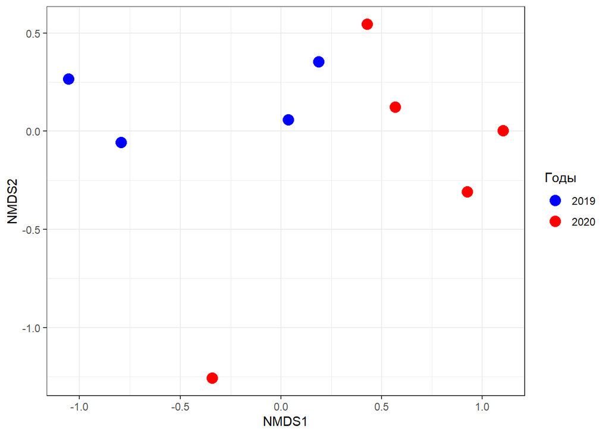

**Рисунок 12.** Ординация станций, взятых в местах техногенного воздействия в 2019 и 2020 гг., в осях многомерного шакалирования.